# Uday_Assignment_2

```python
from google.colab import drive
drive.mount('/content/drive')
```

```python
!unzip /content/drive/MyDrive/dogs-vs-cats.zip
```

```
Archive:  /content/drive/MyDrive/dogs-vs-cats.zip
  inflating: sampleSubmission.csv
  inflating: test1.zip
  inflating: train.zip
```

```python
!unzip /content/train.zip
```

[output not shown]

[output cut: 4946 more lines]

[output not shown]

1. **Consider the Cats & Dogs example. Start initially with a training sample of 1000, a validation sample of 500, and a test sample of 500 (like in the text). Use any technique to reduce overfitting and improve performance in developing a network that you train from scratch. What performance did you achieve?**

We are initially taking the train sample of 1000 by taking first 1000 values in the dataset. Taking 500 validation samples starting from 1000 to 1500 values in the dataset, taking 500 test samples starting from 1500 to 2000 values in the dataset.

```python
import os, shutil, pathlib

original_dir = pathlib.Path("train")
new_base_dir = pathlib.Path("cats_vs_dogs_small_1")

def make_subset(subset_name, start_index, end_index):
    for category in ("cat", "dog"):
        dir = new_base_dir / subset_name / category
        os.makedirs(dir)
        fnames = [f"{category}.{i}.jpg" for i in range(start_index, end_index)]
        for fname in fnames:
            shutil.copyfile(src=original_dir / fname,
                            dst=dir / fname)

make_subset("train", start_index=0, end_index=1000)
make_subset("validation", start_index=1000, end_index=1500)
make_subset("test", start_index=1500, end_index=2000)
```

Here we are preprocessing the data

```python
from tensorflow.keras.utils import image_dataset_from_directory

train_dataset = image_dataset_from_directory(
    new_base_dir / "train",
    image_size=(180, 180),
    batch_size=32)
validation_dataset = image_dataset_from_directory(
    new_base_dir / "validation",
    image_size=(180, 180),
    batch_size=32)
test_dataset = image_dataset_from_directory(
    new_base_dir / "test",
    image_size=(180, 180),
    batch_size=32)
```

```
Found 2000 files belonging to 2 classes.
Found 1000 files belonging to 2 classes.
Found 1000 files belonging to 2 classes.
```

```python
import numpy as np
import tensorflow as tf
random_numbers = np.random.normal(size=(1000, 16))
dataset = tf.data.Dataset.from_tensor_slices(random_numbers)

for i, element in enumerate(dataset):
    print(element.shape)
    if i >= 2:
        break
```

```
(16,)
(16,)
(16,)
```

Here we are taking 32 as batch size for the data

```python
batched_dataset = dataset.batch(32)
for i, element in enumerate(batched_dataset):
    print(element.shape)
    if i >= 2:
        break
```

```
(32, 16)
(32, 16)
(32, 16)
```

Reshaping the dataset using dataset.map

```python
reshaped_dataset = dataset.map(lambda x: tf.reshape(x, (4, 4)))
for i, element in enumerate(reshaped_dataset):
    print(element.shape)
    if i >= 2:
        break
```

```
(4, 4)
(4, 4)
(4, 4)
```

```python
for data_batch, labels_batch in train_dataset:
    print("data batch shape:", data_batch.shape)
    print("labels batch shape:", labels_batch.shape)
    break
```

```
data batch shape: (32, 180, 180, 3)
labels batch shape: (32,)
```

Using Keras with convolutions and Maxpooling: Creates convolutions kernel that is convolved with the layer

```python
from tensorflow import keras
from tensorflow.keras import layers

inputs = keras.Input(shape=(180, 180, 3))
a = layers.Rescaling(1./255)(inputs)
a = layers.Conv2D(filters=32, kernel_size=3, activation="relu")(a)
a = layers.MaxPooling2D(pool_size=2)(a)
a = layers.Conv2D(filters=64, kernel_size=3, activation="relu")(a)
a = layers.MaxPooling2D(pool_size=2)(a)
a = layers.Conv2D(filters=128, kernel_size=3, activation="relu")(a)
a = layers.MaxPooling2D(pool_size=2)(a)
a = layers.Conv2D(filters=256, kernel_size=3, activation="relu")(a)
a = layers.MaxPooling2D(pool_size=2)(a)
a = layers.Conv2D(filters=256, kernel_size=3, activation="relu")(a)
a = layers.Flatten()(a)
a = layers.Dropout(0.5)(a)
outputs = layers.Dense(1, activation="sigmoid")(a)
model = keras.Model(inputs=inputs, outputs=outputs)
```

Configuring the model for training using biary crossentropy as loss function, adam optimizer and accuracy to measure the performance of the model.

```python
model.compile(loss="binary_crossentropy",
              optimizer="adam",
              metrics=["accuracy"])
```

```python
model.summary()
```

```
Model: "functional"
```

```
┏━━━━━━━━━━━━━━━━━━━━━━━━━━━━━━━━━━━━━━┳━━━━━━━━━━━━━━━━━━━━━━━━━━━━━┳━━━━━━━━━━━━━━━━━┓
┃ Layer (type)                         ┃ Output Shape                ┃         Param # ┃
┡━━━━━━━━━━━━━━━━━━━━━━━━━━━━━━━━━━━━━━╇━━━━━━━━━━━━━━━━━━━━━━━━━━━━━╇━━━━━━━━━━━━━━━━━┩
│ input_layer (InputLayer)             │ (None, 180, 180, 3)         │               0 │
├──────────────────────────────────────┼─────────────────────────────┼─────────────────┤
│ rescaling (Rescaling)                │ (None, 180, 180, 3)         │               0 │
├──────────────────────────────────────┼─────────────────────────────┼─────────────────┤
│ conv2d (Conv2D)                      │ (None, 178, 178, 32)        │             896 │
├──────────────────────────────────────┼─────────────────────────────┼─────────────────┤
│ max_pooling2d (MaxPooling2D)         │ (None, 89, 89, 32)          │               0 │
├──────────────────────────────────────┼─────────────────────────────┼─────────────────┤
│ conv2d_1 (Conv2D)                    │ (None, 87, 87, 64)          │          18,496 │
├──────────────────────────────────────┼─────────────────────────────┼─────────────────┤
│ max_pooling2d_1 (MaxPooling2D)       │ (None, 43, 43, 64)          │               0 │
├──────────────────────────────────────┼─────────────────────────────┼─────────────────┤
│ conv2d_2 (Conv2D)                    │ (None, 41, 41, 128)         │          73,856 │
├──────────────────────────────────────┼─────────────────────────────┼─────────────────┤
│ max_pooling2d_2 (MaxPooling2D)       │ (None, 20, 20, 128)         │               0 │
├──────────────────────────────────────┼─────────────────────────────┼─────────────────┤
│ conv2d_3 (Conv2D)                    │ (None, 18, 18, 256)         │         295,168 │
├──────────────────────────────────────┼─────────────────────────────┼─────────────────┤
│ max_pooling2d_3 (MaxPooling2D)       │ (None, 9, 9, 256)           │               0 │
├──────────────────────────────────────┼─────────────────────────────┼─────────────────┤
│ conv2d_4 (Conv2D)                    │ (None, 7, 7, 256)           │         590,080 │
├──────────────────────────────────────┼─────────────────────────────┼─────────────────┤
│ flatten (Flatten)                    │ (None, 12544)               │               0 │
├──────────────────────────────────────┼─────────────────────────────┼─────────────────┤
│ dropout (Dropout)                    │ (None, 12544)               │               0 │
├──────────────────────────────────────┼─────────────────────────────┼─────────────────┤
│ dense (Dense)                        │ (None, 1)                   │          12,545 │
└──────────────────────────────────────┴─────────────────────────────┴─────────────────┘
```

```
 Total params: 991,041 (3.78 MB)
```

```
 Trainable params: 991,041 (3.78 MB)
```

```
 Non-trainable params: 0 (0.00 B)
```

A record of the training measurements and loss values at different epochs, along with validation metrics and loss values, is called a history attribute.

```python
from keras.callbacks import ModelCheckpoint, EarlyStopping

callbacks = [
    keras.callbacks.ModelCheckpoint(
        filepath="convnet_from_scratch.keras",
        save_best_only=True,
        monitor="val_loss")
]
history = model.fit(
    train_dataset,
    epochs=50,
    validation_data=validation_dataset,
    callbacks=callbacks)
```

```
63/63 ━━━━━━━━━━━━━━━━━━━━ 21s 198ms/step - accuracy: 0.4936 - loss: 0.6965 - val_accuracy: 0.5000 - val_loss: 0.6932
63/63 ━━━━━━━━━━━━━━━━━━━━ 5s 61ms/step - accuracy: 0.4827 - loss: 0.6936 - val_accuracy: 0.6060 - val_loss: 0.6746
63/63 ━━━━━━━━━━━━━━━━━━━━ 3s 54ms/step - accuracy: 0.5816 - loss: 0.6840 - val_accuracy: 0.5830 - val_loss: 0.6820
63/63 ━━━━━━━━━━━━━━━━━━━━ 5s 75ms/step - accuracy: 0.5953 - loss: 0.6697 - val_accuracy: 0.6150 - val_loss: 0.6645
63/63 ━━━━━━━━━━━━━━━━━━━━ 5s 83ms/step - accuracy: 0.6528 - loss: 0.6369 - val_accuracy: 0.6570 - val_loss: 0.6268
63/63 ━━━━━━━━━━━━━━━━━━━━ 10s 77ms/step - accuracy: 0.6898 - loss: 0.6029 - val_accuracy: 0.6700 - val_loss: 0.6224
63/63 ━━━━━━━━━━━━━━━━━━━━ 6s 89ms/step - accuracy: 0.7041 - loss: 0.5874 - val_accuracy: 0.6800 - val_loss: 0.5916
63/63 ━━━━━━━━━━━━━━━━━━━━ 4s 63ms/step - accuracy: 0.7192 - loss: 0.5397 - val_accuracy: 0.6980 - val_loss: 0.5808
63/63 ━━━━━━━━━━━━━━━━━━━━ 5s 59ms/step - accuracy: 0.7589 - loss: 0.5033 - val_accuracy: 0.6790 - val_loss: 0.6060
63/63 ━━━━━━━━━━━━━━━━━━━━ 5s 81ms/step - accuracy: 0.7774 - loss: 0.4634 - val_accuracy: 0.7130 - val_loss: 0.5647
63/63 ━━━━━━━━━━━━━━━━━━━━ 5s 86ms/step - accuracy: 0.8140 - loss: 0.3981 - val_accuracy: 0.7290 - val_loss: 0.5558
63/63 ━━━━━━━━━━━━━━━━━━━━ 4s 62ms/step - accuracy: 0.8648 - loss: 0.3186 - val_accuracy: 0.7150 - val_loss: 0.6339
63/63 ━━━━━━━━━━━━━━━━━━━━ 5s 54ms/step - accuracy: 0.8692 - loss: 0.2954 - val_accuracy: 0.7170 - val_loss: 0.6111
63/63 ━━━━━━━━━━━━━━━━━━━━ 6s 98ms/step - accuracy: 0.9016 - loss: 0.2352 - val_accuracy: 0.7410 - val_loss: 0.6178
63/63 ━━━━━━━━━━━━━━━━━━━━ 7s 53ms/step - accuracy: 0.9274 - loss: 0.1802 - val_accuracy: 0.7470 - val_loss: 0.6058
63/63 ━━━━━━━━━━━━━━━━━━━━ 7s 88ms/step - accuracy: 0.9363 - loss: 0.1576 - val_accuracy: 0.7510 - val_loss: 0.7007
63/63 ━━━━━━━━━━━━━━━━━━━━ 8s 52ms/step - accuracy: 0.9511 - loss: 0.1200 - val_accuracy: 0.7390 - val_loss: 0.8082
63/63 ━━━━━━━━━━━━━━━━━━━━ 4s 58ms/step - accuracy: 0.9606 - loss: 0.1063 - val_accuracy: 0.7520 - val_loss: 0.8600
63/63 ━━━━━━━━━━━━━━━━━━━━ 7s 104ms/step - accuracy: 0.9549 - loss: 0.1135 - val_accuracy: 0.7590 - val_loss: 0.8964
63/63 ━━━━━━━━━━━━━━━━━━━━ 7s 53ms/step - accuracy: 0.9828 - loss: 0.0610 - val_accuracy: 0.7440 - val_loss: 0.9177
63/63 ━━━━━━━━━━━━━━━━━━━━ 4s 57ms/step - accuracy: 0.9785 - loss: 0.0698 - val_accuracy: 0.7480 - val_loss: 0.9656
63/63 ━━━━━━━━━━━━━━━━━━━━ 6s 91ms/step - accuracy: 0.9783 - loss: 0.0623 - val_accuracy: 0.7660 - val_loss: 1.0373
63/63 ━━━━━━━━━━━━━━━━━━━━ 4s 58ms/step - accuracy: 0.9829 - loss: 0.0430 - val_accuracy: 0.7730 - val_loss: 0.9390
63/63 ━━━━━━━━━━━━━━━━━━━━ 5s 58ms/step - accuracy: 0.9879 - loss: 0.0351 - val_accuracy: 0.7410 - val_loss: 0.9775
63/63 ━━━━━━━━━━━━━━━━━━━━ 5s 82ms/step - accuracy: 0.9846 - loss: 0.0411 - val_accuracy: 0.7480 - val_loss: 1.1086
63/63 ━━━━━━━━━━━━━━━━━━━━ 5s 73ms/step - accuracy: 0.9866 - loss: 0.0348 - val_accuracy: 0.7570 - val_loss: 0.9876
63/63 ━━━━━━━━━━━━━━━━━━━━ 4s 58ms/step - accuracy: 0.9877 - loss: 0.0422 - val_accuracy: 0.7560 - val_loss: 1.1421
63/63 ━━━━━━━━━━━━━━━━━━━━ 5s 59ms/step - accuracy: 0.9867 - loss: 0.0369 - val_accuracy: 0.7550 - val_loss: 1.0523
63/63 ━━━━━━━━━━━━━━━━━━━━ 7s 85ms/step - accuracy: 0.9887 - loss: 0.0321 - val_accuracy: 0.7540 - val_loss: 1.0905
63/63 ━━━━━━━━━━━━━━━━━━━━ 8s 52ms/step - accuracy: 0.9937 - loss: 0.0272 - val_accuracy: 0.7420 - val_loss: 1.2064
63/63 ━━━━━━━━━━━━━━━━━━━━ 6s 94ms/step - accuracy: 0.9899 - loss: 0.0360 - val_accuracy: 0.7480 - val_loss: 1.1218
63/63 ━━━━━━━━━━━━━━━━━━━━ 8s 53ms/step - accuracy: 0.9912 - loss: 0.0305 - val_accuracy: 0.7490 - val_loss: 1.2073
63/63 ━━━━━━━━━━━━━━━━━━━━ 8s 94ms/step - accuracy: 0.9931 - loss: 0.0218 - val_accuracy: 0.7550 - val_loss: 1.2128
63/63 ━━━━━━━━━━━━━━━━━━━━ 8s 59ms/step - accuracy: 0.9951 - loss: 0.0148 - val_accuracy: 0.7640 - val_loss: 1.2223
63/63 ━━━━━━━━━━━━━━━━━━━━ 5s 53ms/step - accuracy: 0.9939 - loss: 0.0175 - val_accuracy: 0.7640 - val_loss: 1.2819
63/63 ━━━━━━━━━━━━━━━━━━━━ 6s 90ms/step - accuracy: 0.9937 - loss: 0.0208 - val_accuracy: 0.7600 - val_loss: 1.3270
63/63 ━━━━━━━━━━━━━━━━━━━━ 5s 73ms/step - accuracy: 0.9969 - loss: 0.0083 - val_accuracy: 0.7430 - val_loss: 1.5207
63/63 ━━━━━━━━━━━━━━━━━━━━ 4s 60ms/step - accuracy: 0.9938 - loss: 0.0167 - val_accuracy: 0.7580 - val_loss: 1.3930
63/63 ━━━━━━━━━━━━━━━━━━━━ 3s 55ms/step - accuracy: 0.9872 - loss: 0.0435 - val_accuracy: 0.7520 - val_loss: 1.3997
63/63 ━━━━━━━━━━━━━━━━━━━━ 7s 88ms/step - accuracy: 0.9801 - loss: 0.0481 - val_accuracy: 0.7490 - val_loss: 1.2285
63/63 ━━━━━━━━━━━━━━━━━━━━ 3s 54ms/step - accuracy: 0.9886 - loss: 0.0331 - val_accuracy: 0.7640 - val_loss: 1.2702
63/63 ━━━━━━━━━━━━━━━━━━━━ 4s 59ms/step - accuracy: 0.9972 - loss: 0.0124 - val_accuracy: 0.7680 - val_loss: 1.2822
63/63 ━━━━━━━━━━━━━━━━━━━━ 6s 76ms/step - accuracy: 0.9917 - loss: 0.0308 - val_accuracy: 0.7410 - val_loss: 1.4839
63/63 ━━━━━━━━━━━━━━━━━━━━ 5s 76ms/step - accuracy: 0.9864 - loss: 0.0466 - val_accuracy: 0.7670 - val_loss: 1.2331
63/63 ━━━━━━━━━━━━━━━━━━━━ 4s 57ms/step - accuracy: 0.9862 - loss: 0.0514 - val_accuracy: 0.7410 - val_loss: 1.1982
63/63 ━━━━━━━━━━━━━━━━━━━━ 4s 57ms/step - accuracy: 0.9879 - loss: 0.0380 - val_accuracy: 0.7560 - val_loss: 1.3930
63/63 ━━━━━━━━━━━━━━━━━━━━ 5s 82ms/step - accuracy: 0.9951 - loss: 0.0199 - val_accuracy: 0.7520 - val_loss: 1.3849
63/63 ━━━━━━━━━━━━━━━━━━━━ 9s 57ms/step - accuracy: 0.9928 - loss: 0.0258 - val_accuracy: 0.7670 - val_loss: 1.4238
63/63 ━━━━━━━━━━━━━━━━━━━━ 7s 88ms/step - accuracy: 0.9909 - loss: 0.0321 - val_accuracy: 0.7560 - val_loss: 1.3836
63/63 ━━━━━━━━━━━━━━━━━━━━ 8s 56ms/step - accuracy: 0.9889 - loss: 0.0375 - val_accuracy: 0.7530 - val_loss: 1.3339
```

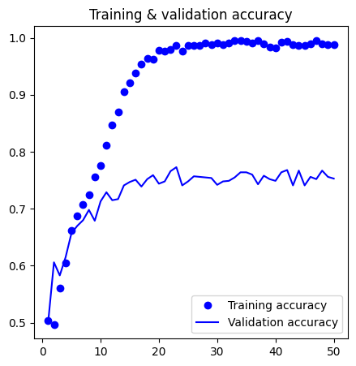

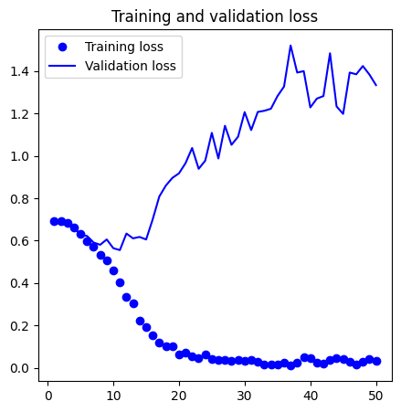

```python
import matplotlib.pyplot as plt

plt.figure(figsize=(5, 5))
accuracy = history.history["accuracy"]
val_accuracy = history.history["val_accuracy"]
loss = history.history["loss"]
val_loss = history.history["val_loss"]
epochs = range(1, len(accuracy) + 1)
plt.plot(epochs, accuracy, "bo", label="Training accuracy")
plt.plot(epochs, val_accuracy, "b", label="Validation accuracy")
plt.title("Training & validation accuracy")
plt.legend()
plt.figure()
plt.figure(figsize=(5, 5))
plt.plot(epochs, loss, "bo", label="Training loss")
plt.plot(epochs, val_loss, "b", label="Validation loss")
plt.title("Training and validation loss")
plt.legend()
plt.show()
```

```python
test_model = keras.models.load_model("convnet_from_scratch.keras")
test_loss, test_acc = test_model.evaluate(test_dataset)
print(f"Test accuracy: {test_acc:.3f}")
```

```
32/32 ━━━━━━━━━━━━━━━━━━━━ 2s 47ms/step - accuracy: 0.7092 - loss: 0.5987
Test accuracy: 0.701
```

1. **Increase your training sample size. You may pick any amount. Keep the validation and test samples the same as above. Optimize your network (again training from scratch). What performance did you achieve?**

```python
import os, shutil, pathlib

shutil.rmtree("./cats_vs_dogs_small_Q2", ignore_errors=True)

original_dir = pathlib.Path("train")
new_base_dir = pathlib.Path("cats_vs_dogs_small_Q2")

def make_subset(subset_name, start_index, end_index):
    for category in ("cat", "dog"):
        dir = new_base_dir / subset_name / category
        os.makedirs(dir)
        fnames = [f"{category}.{i}.jpg" for i in range(start_index, end_index)]
        for fname in fnames:
            shutil.copyfile(src=original_dir / fname,
                            dst=dir / fname)
#Creating training, Test and validation sets.
#Training has 1500 samples, test has 500 samples and validation has 500 samples.
make_subset("train", start_index=2000, end_index=3500)
make_subset("validation", start_index=3501, end_index=4001)
make_subset("test", start_index=4002, end_index=4502)
```

```python
data_augmentation = keras.Sequential(
    [
        layers.RandomFlip("horizontal"),
        layers.RandomRotation(0.1),
        layers.RandomZoom(0.2),
    ]
)
```

Display of few sample images in the dataset.

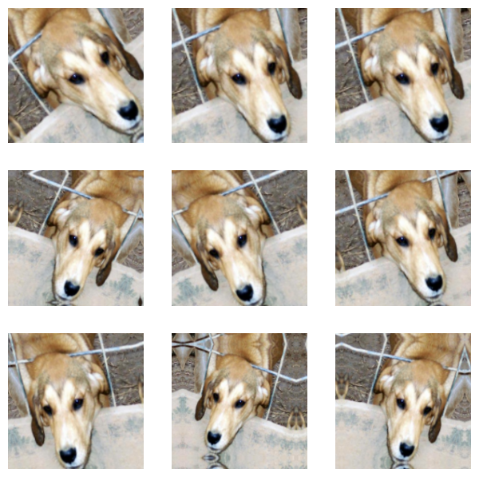

```python
plt.figure(figsize=(7.5,7.5 ))
for images, _ in train_dataset.take(1):
    for i in range(9):
        augmented_images = data_augmentation(images)
        ax = plt.subplot(3, 3, i + 1)
        plt.imshow(augmented_images[0].numpy().astype("uint8"))
        plt.axis("off")
```

Using Data Augmentation and Dropout to optimize the model. Dropout layer only applies when training is set to True such that no values are dropped during inference

```python
inputs = keras.Input(shape=(180, 180, 3))
x = data_augmentation(inputs)
x = layers.Rescaling(1./255)(x)
x = layers.Conv2D(filters=32, kernel_size=3, activation="relu")(x)
x = layers.MaxPooling2D(pool_size=2)(x)
x = layers.Conv2D(filters=64, kernel_size=3, activation="relu")(x)
x = layers.MaxPooling2D(pool_size=2)(x)
x = layers.Conv2D(filters=128, kernel_size=3, activation="relu")(x)
x = layers.MaxPooling2D(pool_size=2)(x)
x = layers.Conv2D(filters=256, kernel_size=3, activation="relu")(x)
x = layers.MaxPooling2D(pool_size=2)(x)
x = layers.Conv2D(filters=256, kernel_size=3, activation="relu")(x)
x = layers.Flatten()(x)
x = layers.Dropout(0.5)(x)
outputs = layers.Dense(1, activation="sigmoid")(x)
model = keras.Model(inputs=inputs, outputs=outputs)

model.compile(loss="binary_crossentropy",
              optimizer="adam",
              metrics=["accuracy"])

callbacks = [
    keras.callbacks.ModelCheckpoint(
        filepath="convnet_from_scratch_with_augmentation.keras",
        save_best_only=True,
        monitor="val_loss")
]
history = model.fit(
    train_dataset,
    epochs=100,
    validation_data=validation_dataset,
    callbacks=callbacks)
```

```
63/63 ━━━━━━━━━━━━━━━━━━━━ 10s 72ms/step - accuracy: 0.5133 - loss: 0.6973 - val_accuracy: 0.5000 - val_loss: 0.6930
63/63 ━━━━━━━━━━━━━━━━━━━━ 5s 81ms/step - accuracy: 0.5100 - loss: 0.6945 - val_accuracy: 0.5000 - val_loss: 0.6933
63/63 ━━━━━━━━━━━━━━━━━━━━ 5s 78ms/step - accuracy: 0.5084 - loss: 0.6935 - val_accuracy: 0.5000 - val_loss: 0.6934
63/63 ━━━━━━━━━━━━━━━━━━━━ 4s 56ms/step - accuracy: 0.4756 - loss: 0.6938 - val_accuracy: 0.5030 - val_loss: 0.7008
63/63 ━━━━━━━━━━━━━━━━━━━━ 4s 62ms/step - accuracy: 0.4824 - loss: 0.6996 - val_accuracy: 0.4960 - val_loss: 0.6959
63/63 ━━━━━━━━━━━━━━━━━━━━ 5s 84ms/step - accuracy: 0.5138 - loss: 0.6935 - val_accuracy: 0.5000 - val_loss: 0.6933
63/63 ━━━━━━━━━━━━━━━━━━━━ 5s 80ms/step - accuracy: 0.4829 - loss: 0.6937 - val_accuracy: 0.5010 - val_loss: 0.6931
63/63 ━━━━━━━━━━━━━━━━━━━━ 4s 61ms/step - accuracy: 0.4910 - loss: 0.6932 - val_accuracy: 0.5040 - val_loss: 0.6979
63/63 ━━━━━━━━━━━━━━━━━━━━ 6s 83ms/step - accuracy: 0.5067 - loss: 0.6933 - val_accuracy: 0.5100 - val_loss: 0.6934
63/63 ━━━━━━━━━━━━━━━━━━━━ 9s 56ms/step - accuracy: 0.4820 - loss: 0.6933 - val_accuracy: 0.5000 - val_loss: 0.6931
63/63 ━━━━━━━━━━━━━━━━━━━━ 4s 58ms/step - accuracy: 0.4899 - loss: 0.6933 - val_accuracy: 0.5260 - val_loss: 0.6897
63/63 ━━━━━━━━━━━━━━━━━━━━ 7s 84ms/step - accuracy: 0.5142 - loss: 0.7025 - val_accuracy: 0.5000 - val_loss: 0.6934
63/63 ━━━━━━━━━━━━━━━━━━━━ 9s 62ms/step - accuracy: 0.4937 - loss: 0.6936 - val_accuracy: 0.5000 - val_loss: 0.6932
63/63 ━━━━━━━━━━━━━━━━━━━━ 6s 102ms/step - accuracy: 0.5027 - loss: 0.6934 - val_accuracy: 0.5000 - val_loss: 0.6937
63/63 ━━━━━━━━━━━━━━━━━━━━ 4s 60ms/step - accuracy: 0.4714 - loss: 0.6939 - val_accuracy: 0.5000 - val_loss: 0.6931
63/63 ━━━━━━━━━━━━━━━━━━━━ 4s 57ms/step - accuracy: 0.5039 - loss: 0.6930 - val_accuracy: 0.5220 - val_loss: 0.6883
63/63 ━━━━━━━━━━━━━━━━━━━━ 4s 62ms/step - accuracy: 0.5539 - loss: 0.6837 - val_accuracy: 0.5200 - val_loss: 0.6932
63/63 ━━━━━━━━━━━━━━━━━━━━ 6s 92ms/step - accuracy: 0.5445 - loss: 0.6920 - val_accuracy: 0.5260 - val_loss: 0.6884
63/63 ━━━━━━━━━━━━━━━━━━━━ 8s 58ms/step - accuracy: 0.5958 - loss: 0.6815 - val_accuracy: 0.5290 - val_loss: 0.6859
63/63 ━━━━━━━━━━━━━━━━━━━━ 7s 86ms/step - accuracy: 0.5749 - loss: 0.6741 - val_accuracy: 0.5510 - val_loss: 0.6850
63/63 ━━━━━━━━━━━━━━━━━━━━ 5s 77ms/step - accuracy: 0.6046 - loss: 0.6613 - val_accuracy: 0.5570 - val_loss: 0.6794
63/63 ━━━━━━━━━━━━━━━━━━━━ 4s 57ms/step - accuracy: 0.5956 - loss: 0.6639 - val_accuracy: 0.5950 - val_loss: 0.6661
63/63 ━━━━━━━━━━━━━━━━━━━━ 4s 63ms/step - accuracy: 0.6227 - loss: 0.6544 - val_accuracy: 0.6240 - val_loss: 0.6576
63/63 ━━━━━━━━━━━━━━━━━━━━ 7s 92ms/step - accuracy: 0.6276 - loss: 0.6478 - val_accuracy: 0.6120 - val_loss: 0.6526
63/63 ━━━━━━━━━━━━━━━━━━━━ 8s 56ms/step - accuracy: 0.6375 - loss: 0.6396 - val_accuracy: 0.6170 - val_loss: 0.6568
63/63 ━━━━━━━━━━━━━━━━━━━━ 7s 88ms/step - accuracy: 0.6346 - loss: 0.6365 - val_accuracy: 0.6070 - val_loss: 0.6512
63/63 ━━━━━━━━━━━━━━━━━━━━ 6s 94ms/step - accuracy: 0.6406 - loss: 0.6380 - val_accuracy: 0.6250 - val_loss: 0.6427
63/63 ━━━━━━━━━━━━━━━━━━━━ 6s 89ms/step - accuracy: 0.6627 - loss: 0.6213 - val_accuracy: 0.6550 - val_loss: 0.6275
63/63 ━━━━━━━━━━━━━━━━━━━━ 5s 82ms/step - accuracy: 0.6467 - loss: 0.6162 - val_accuracy: 0.6370 - val_loss: 0.6357
63/63 ━━━━━━━━━━━━━━━━━━━━ 9s 62ms/step - accuracy: 0.6647 - loss: 0.6189 - val_accuracy: 0.6410 - val_loss: 0.6292
63/63 ━━━━━━━━━━━━━━━━━━━━ 4s 64ms/step - accuracy: 0.6663 - loss: 0.6050 - val_accuracy: 0.6490 - val_loss: 0.6190
63/63 ━━━━━━━━━━━━━━━━━━━━ 6s 93ms/step - accuracy: 0.6737 - loss: 0.6071 - val_accuracy: 0.6400 - val_loss: 0.6292
63/63 ━━━━━━━━━━━━━━━━━━━━ 8s 58ms/step - accuracy: 0.6861 - loss: 0.5995 - val_accuracy: 0.6800 - val_loss: 0.6039
63/63 ━━━━━━━━━━━━━━━━━━━━ 7s 84ms/step - accuracy: 0.6751 - loss: 0.5926 - val_accuracy: 0.6600 - val_loss: 0.6100
63/63 ━━━━━━━━━━━━━━━━━━━━ 5s 78ms/step - accuracy: 0.6962 - loss: 0.5838 - val_accuracy: 0.6710 - val_loss: 0.6023
63/63 ━━━━━━━━━━━━━━━━━━━━ 4s 58ms/step - accuracy: 0.6933 - loss: 0.5851 - val_accuracy: 0.7020 - val_loss: 0.5880
63/63 ━━━━━━━━━━━━━━━━━━━━ 4s 62ms/step - accuracy: 0.7176 - loss: 0.5643 - val_accuracy: 0.6770 - val_loss: 0.5985
63/63 ━━━━━━━━━━━━━━━━━━━━ 5s 82ms/step - accuracy: 0.7128 - loss: 0.5530 - val_accuracy: 0.6760 - val_loss: 0.6038
63/63 ━━━━━━━━━━━━━━━━━━━━ 5s 84ms/step - accuracy: 0.6966 - loss: 0.5696 - val_accuracy: 0.7030 - val_loss: 0.5726
63/63 ━━━━━━━━━━━━━━━━━━━━ 9s 60ms/step - accuracy: 0.7151 - loss: 0.5379 - val_accuracy: 0.7080 - val_loss: 0.5689
```

[output cut: 45 more lines]

```
63/63 ━━━━━━━━━━━━━━━━━━━━ 6s 88ms/step - accuracy: 0.8546 - loss: 0.3402 - val_accuracy: 0.7450 - val_loss: 0.5041
63/63 ━━━━━━━━━━━━━━━━━━━━ 4s 56ms/step - accuracy: 0.8353 - loss: 0.3646 - val_accuracy: 0.7780 - val_loss: 0.4834
63/63 ━━━━━━━━━━━━━━━━━━━━ 4s 62ms/step - accuracy: 0.8704 - loss: 0.3156 - val_accuracy: 0.7780 - val_loss: 0.4808
63/63 ━━━━━━━━━━━━━━━━━━━━ 7s 100ms/step - accuracy: 0.8515 - loss: 0.3283 - val_accuracy: 0.7950 - val_loss: 0.4665
63/63 ━━━━━━━━━━━━━━━━━━━━ 8s 62ms/step - accuracy: 0.8649 - loss: 0.3171 - val_accuracy: 0.7710 - val_loss: 0.5127
63/63 ━━━━━━━━━━━━━━━━━━━━ 4s 64ms/step - accuracy: 0.8547 - loss: 0.3281 - val_accuracy: 0.7710 - val_loss: 0.5110
63/63 ━━━━━━━━━━━━━━━━━━━━ 7s 89ms/step - accuracy: 0.8693 - loss: 0.3142 - val_accuracy: 0.7880 - val_loss: 0.4830
63/63 ━━━━━━━━━━━━━━━━━━━━ 4s 56ms/step - accuracy: 0.8799 - loss: 0.2873 - val_accuracy: 0.7780 - val_loss: 0.5115
63/63 ━━━━━━━━━━━━━━━━━━━━ 5s 62ms/step - accuracy: 0.8641 - loss: 0.3233 - val_accuracy: 0.7800 - val_loss: 0.4839
63/63 ━━━━━━━━━━━━━━━━━━━━ 6s 91ms/step - accuracy: 0.8676 - loss: 0.3115 - val_accuracy: 0.7790 - val_loss: 0.4863
63/63 ━━━━━━━━━━━━━━━━━━━━ 8s 57ms/step - accuracy: 0.8673 - loss: 0.3171 - val_accuracy: 0.7630 - val_loss: 0.5077
63/63 ━━━━━━━━━━━━━━━━━━━━ 4s 66ms/step - accuracy: 0.8692 - loss: 0.2899 - val_accuracy: 0.7590 - val_loss: 0.5473
63/63 ━━━━━━━━━━━━━━━━━━━━ 7s 91ms/step - accuracy: 0.8653 - loss: 0.2938 - val_accuracy: 0.7690 - val_loss: 0.5158
63/63 ━━━━━━━━━━━━━━━━━━━━ 8s 56ms/step - accuracy: 0.8854 - loss: 0.2773 - val_accuracy: 0.7840 - val_loss: 0.5011
63/63 ━━━━━━━━━━━━━━━━━━━━ 6s 101ms/step - accuracy: 0.8689 - loss: 0.3007 - val_accuracy: 0.7850 - val_loss: 0.5102
```

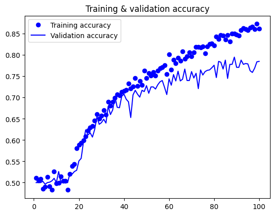

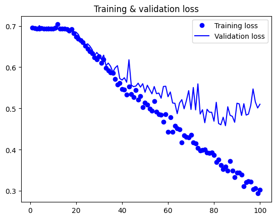

```python
import matplotlib.pyplot as plt
accuracy = history.history["accuracy"]
val_accuracy = history.history["val_accuracy"]
loss = history.history["loss"]
val_loss = history.history["val_loss"]
epochs = range(1, len(accuracy) + 1)
plt.plot(epochs, accuracy, "bo", label="Training accuracy")
plt.plot(epochs, val_accuracy, "b", label="Validation accuracy")
plt.title("Training & validation accuracy")
plt.legend()
plt.figure()
plt.plot(epochs, loss, "bo", label="Training loss")
plt.plot(epochs, val_loss, "b", label="Validation loss")
plt.title("Training & validation loss")
plt.legend()
plt.show()
```

```python
test_model = keras.models.load_model(
    "convnet_from_scratch_with_augmentation.keras")
test_loss, test_acc = test_model.evaluate(test_dataset)
print(f"Test accuracy: {test_acc:.3f}")
```

```
32/32 ━━━━━━━━━━━━━━━━━━━━ 1s 29ms/step - accuracy: 0.7922 - loss: 0.4741
Test accuracy: 0.786
```

1. **Now change your training sample so that you achieve better performance than those from Steps 1 and 2. This sample size may be larger, or smaller than those in the previous steps. The objective is to find the ideal training sample size to get best prediction results.**

```python
original_dir = pathlib.Path("train")
new_base_dir = pathlib.Path("cats_vs_dogs_small_Q3")

def make_subset(subset_name, start_index, end_index):
    for category in ("cat", "dog"):
        dir = new_base_dir / subset_name / category
        os.makedirs(dir)
        fnames = [f"{category}.{i}.jpg" for i in range(start_index, end_index)]
        for fname in fnames:
            shutil.copyfile(src=original_dir / fname,
                            dst=dir / fname)
#Creating training, Test and validation sets.
#Training has 2000 samples, test has 500 samples and validation has 500 samples.
make_subset("train", start_index=4000, end_index=6000)
make_subset("validation", start_index=6001, end_index=6501)
make_subset("test", start_index=6502, end_index=7002)
```

A new convent:

```python
inputs = keras.Input(shape=(180, 180, 3))
x = data_augmentation(inputs)
x = layers.Rescaling(1./255)(x)
x = layers.Conv2D(filters=32, kernel_size=3, activation="relu")(x)
x = layers.MaxPooling2D(pool_size=2)(x)
x = layers.Conv2D(filters=64, kernel_size=3, activation="relu")(x)
x = layers.MaxPooling2D(pool_size=2)(x)
x = layers.Conv2D(filters=128, kernel_size=3, activation="relu")(x)
x = layers.MaxPooling2D(pool_size=2)(x)
x = layers.Conv2D(filters=256, kernel_size=3, activation="relu")(x)
x = layers.MaxPooling2D(pool_size=2)(x)
x = layers.Conv2D(filters=256, kernel_size=3, activation="relu")(x)
x = layers.Flatten()(x)
x = layers.Dropout(0.5)(x)
outputs = layers.Dense(1, activation="sigmoid")(x)
model = keras.Model(inputs=inputs, outputs=outputs)

model.compile(loss="binary_crossentropy",
              optimizer="adam",
              metrics=["accuracy"])
```

```python
callbacks = [
    keras.callbacks.ModelCheckpoint(
        filepath="convnet_from_scratch_with_augmentation1.keras",
        save_best_only=True,
        monitor="val_loss")
]
history = model.fit(
    train_dataset,
    epochs=75,
    validation_data=validation_dataset,
    callbacks=callbacks)
```

```
63/63 ━━━━━━━━━━━━━━━━━━━━ 8s 95ms/step - accuracy: 0.5286 - loss: 0.6965 - val_accuracy: 0.5000 - val_loss: 0.6935
63/63 ━━━━━━━━━━━━━━━━━━━━ 8s 64ms/step - accuracy: 0.4894 - loss: 0.6939 - val_accuracy: 0.5000 - val_loss: 0.6932
63/63 ━━━━━━━━━━━━━━━━━━━━ 7s 91ms/step - accuracy: 0.4884 - loss: 0.6935 - val_accuracy: 0.5000 - val_loss: 0.6932
63/63 ━━━━━━━━━━━━━━━━━━━━ 5s 71ms/step - accuracy: 0.4885 - loss: 0.6936 - val_accuracy: 0.5000 - val_loss: 0.6935
63/63 ━━━━━━━━━━━━━━━━━━━━ 4s 56ms/step - accuracy: 0.4793 - loss: 0.6938 - val_accuracy: 0.5000 - val_loss: 0.6950
63/63 ━━━━━━━━━━━━━━━━━━━━ 4s 57ms/step - accuracy: 0.4828 - loss: 0.6948 - val_accuracy: 0.5000 - val_loss: 0.6931
63/63 ━━━━━━━━━━━━━━━━━━━━ 7s 104ms/step - accuracy: 0.5217 - loss: 0.6959 - val_accuracy: 0.5000 - val_loss: 0.6933
63/63 ━━━━━━━━━━━━━━━━━━━━ 4s 64ms/step - accuracy: 0.4820 - loss: 0.6935 - val_accuracy: 0.5000 - val_loss: 0.6930
63/63 ━━━━━━━━━━━━━━━━━━━━ 4s 56ms/step - accuracy: 0.4850 - loss: 0.6932 - val_accuracy: 0.5000 - val_loss: 0.6935
63/63 ━━━━━━━━━━━━━━━━━━━━ 4s 65ms/step - accuracy: 0.4848 - loss: 0.6937 - val_accuracy: 0.5000 - val_loss: 0.6933
63/63 ━━━━━━━━━━━━━━━━━━━━ 6s 79ms/step - accuracy: 0.4897 - loss: 0.6935 - val_accuracy: 0.5300 - val_loss: 0.6930
63/63 ━━━━━━━━━━━━━━━━━━━━ 4s 61ms/step - accuracy: 0.5181 - loss: 0.6919 - val_accuracy: 0.4900 - val_loss: 0.6934
63/63 ━━━━━━━━━━━━━━━━━━━━ 5s 62ms/step - accuracy: 0.5280 - loss: 0.6911 - val_accuracy: 0.5000 - val_loss: 0.6925
63/63 ━━━━━━━━━━━━━━━━━━━━ 7s 107ms/step - accuracy: 0.5099 - loss: 0.6900 - val_accuracy: 0.5010 - val_loss: 0.6931
63/63 ━━━━━━━━━━━━━━━━━━━━ 4s 56ms/step - accuracy: 0.4822 - loss: 0.6933 - val_accuracy: 0.5000 - val_loss: 0.6932
63/63 ━━━━━━━━━━━━━━━━━━━━ 4s 56ms/step - accuracy: 0.5221 - loss: 0.6929 - val_accuracy: 0.5020 - val_loss: 0.6931
63/63 ━━━━━━━━━━━━━━━━━━━━ 7s 84ms/step - accuracy: 0.5132 - loss: 0.6931 - val_accuracy: 0.5150 - val_loss: 0.6928
63/63 ━━━━━━━━━━━━━━━━━━━━ 5s 82ms/step - accuracy: 0.5022 - loss: 0.6917 - val_accuracy: 0.5020 - val_loss: 0.6865
63/63 ━━━━━━━━━━━━━━━━━━━━ 10s 83ms/step - accuracy: 0.5067 - loss: 0.6882 - val_accuracy: 0.5000 - val_loss: 0.6932
63/63 ━━━━━━━━━━━━━━━━━━━━ 5s 82ms/step - accuracy: 0.5234 - loss: 0.6927 - val_accuracy: 0.5000 - val_loss: 0.6932
63/63 ━━━━━━━━━━━━━━━━━━━━ 3s 55ms/step - accuracy: 0.5070 - loss: 0.6932 - val_accuracy: 0.5000 - val_loss: 0.6931
63/63 ━━━━━━━━━━━━━━━━━━━━ 5s 57ms/step - accuracy: 0.4898 - loss: 0.6933 - val_accuracy: 0.5000 - val_loss: 0.6932
63/63 ━━━━━━━━━━━━━━━━━━━━ 7s 84ms/step - accuracy: 0.5121 - loss: 0.6933 - val_accuracy: 0.5010 - val_loss: 0.6931
63/63 ━━━━━━━━━━━━━━━━━━━━ 4s 56ms/step - accuracy: 0.5072 - loss: 0.6931 - val_accuracy: 0.5000 - val_loss: 0.6931
63/63 ━━━━━━━━━━━━━━━━━━━━ 5s 62ms/step - accuracy: 0.5081 - loss: 0.6931 - val_accuracy: 0.4960 - val_loss: 0.6913
63/63 ━━━━━━━━━━━━━━━━━━━━ 7s 87ms/step - accuracy: 0.5053 - loss: 0.6931 - val_accuracy: 0.4830 - val_loss: 0.6933
63/63 ━━━━━━━━━━━━━━━━━━━━ 3s 55ms/step - accuracy: 0.5149 - loss: 0.6936 - val_accuracy: 0.5010 - val_loss: 0.6931
63/63 ━━━━━━━━━━━━━━━━━━━━ 6s 62ms/step - accuracy: 0.4894 - loss: 0.6932 - val_accuracy: 0.5010 - val_loss: 0.6931
63/63 ━━━━━━━━━━━━━━━━━━━━ 6s 89ms/step - accuracy: 0.4614 - loss: 0.6934 - val_accuracy: 0.5000 - val_loss: 0.6931
63/63 ━━━━━━━━━━━━━━━━━━━━ 5s 75ms/step - accuracy: 0.4749 - loss: 0.6932 - val_accuracy: 0.5000 - val_loss: 0.6931
63/63 ━━━━━━━━━━━━━━━━━━━━ 4s 55ms/step - accuracy: 0.4818 - loss: 0.6942 - val_accuracy: 0.5130 - val_loss: 0.6930
63/63 ━━━━━━━━━━━━━━━━━━━━ 7s 86ms/step - accuracy: 0.5091 - loss: 0.6928 - val_accuracy: 0.5120 - val_loss: 0.6904
63/63 ━━━━━━━━━━━━━━━━━━━━ 5s 74ms/step - accuracy: 0.5402 - loss: 0.6895 - val_accuracy: 0.4930 - val_loss: 0.6892
63/63 ━━━━━━━━━━━━━━━━━━━━ 4s 61ms/step - accuracy: 0.5505 - loss: 0.6876 - val_accuracy: 0.5000 - val_loss: 0.6934
63/63 ━━━━━━━━━━━━━━━━━━━━ 4s 63ms/step - accuracy: 0.5325 - loss: 0.6915 - val_accuracy: 0.5890 - val_loss: 0.6815
63/63 ━━━━━━━━━━━━━━━━━━━━ 7s 94ms/step - accuracy: 0.5500 - loss: 0.6786 - val_accuracy: 0.5940 - val_loss: 0.6658
63/63 ━━━━━━━━━━━━━━━━━━━━ 8s 58ms/step - accuracy: 0.6069 - loss: 0.6631 - val_accuracy: 0.6350 - val_loss: 0.6534
63/63 ━━━━━━━━━━━━━━━━━━━━ 6s 91ms/step - accuracy: 0.6257 - loss: 0.6541 - val_accuracy: 0.6270 - val_loss: 0.6425
63/63 ━━━━━━━━━━━━━━━━━━━━ 5s 72ms/step - accuracy: 0.6038 - loss: 0.6722 - val_accuracy: 0.6170 - val_loss: 0.6425
63/63 ━━━━━━━━━━━━━━━━━━━━ 4s 63ms/step - accuracy: 0.6019 - loss: 0.6628 - val_accuracy: 0.6280 - val_loss: 0.6411
```

[output cut: 20 more lines]

```
63/63 ━━━━━━━━━━━━━━━━━━━━ 8s 57ms/step - accuracy: 0.7473 - loss: 0.5021 - val_accuracy: 0.7410 - val_loss: 0.5065
63/63 ━━━━━━━━━━━━━━━━━━━━ 8s 109ms/step - accuracy: 0.7800 - loss: 0.4818 - val_accuracy: 0.7430 - val_loss: 0.4981
63/63 ━━━━━━━━━━━━━━━━━━━━ 7s 58ms/step - accuracy: 0.7712 - loss: 0.4781 - val_accuracy: 0.7690 - val_loss: 0.4738
63/63 ━━━━━━━━━━━━━━━━━━━━ 6s 92ms/step - accuracy: 0.7888 - loss: 0.4573 - val_accuracy: 0.7630 - val_loss: 0.4783
63/63 ━━━━━━━━━━━━━━━━━━━━ 4s 68ms/step - accuracy: 0.7963 - loss: 0.4440 - val_accuracy: 0.7570 - val_loss: 0.5016
63/63 ━━━━━━━━━━━━━━━━━━━━ 4s 56ms/step - accuracy: 0.7888 - loss: 0.4675 - val_accuracy: 0.7540 - val_loss: 0.4952
63/63 ━━━━━━━━━━━━━━━━━━━━ 6s 75ms/step - accuracy: 0.7906 - loss: 0.4566 - val_accuracy: 0.7690 - val_loss: 0.4696
63/63 ━━━━━━━━━━━━━━━━━━━━ 7s 112ms/step - accuracy: 0.7981 - loss: 0.4386 - val_accuracy: 0.7690 - val_loss: 0.4798
63/63 ━━━━━━━━━━━━━━━━━━━━ 7s 57ms/step - accuracy: 0.7817 - loss: 0.4501 - val_accuracy: 0.7570 - val_loss: 0.4770
63/63 ━━━━━━━━━━━━━━━━━━━━ 8s 101ms/step - accuracy: 0.7945 - loss: 0.4303 - val_accuracy: 0.7660 - val_loss: 0.4850
63/63 ━━━━━━━━━━━━━━━━━━━━ 8s 64ms/step - accuracy: 0.7894 - loss: 0.4389 - val_accuracy: 0.7980 - val_loss: 0.4464
63/63 ━━━━━━━━━━━━━━━━━━━━ 5s 84ms/step - accuracy: 0.8057 - loss: 0.4164 - val_accuracy: 0.8110 - val_loss: 0.4454
63/63 ━━━━━━━━━━━━━━━━━━━━ 9s 62ms/step - accuracy: 0.7899 - loss: 0.4272 - val_accuracy: 0.7920 - val_loss: 0.4523
63/63 ━━━━━━━━━━━━━━━━━━━━ 4s 63ms/step - accuracy: 0.8189 - loss: 0.3931 - val_accuracy: 0.8040 - val_loss: 0.4303
63/63 ━━━━━━━━━━━━━━━━━━━━ 6s 94ms/step - accuracy: 0.8216 - loss: 0.3939 - val_accuracy: 0.7900 - val_loss: 0.4544
```

Graph of training and validation accuracy

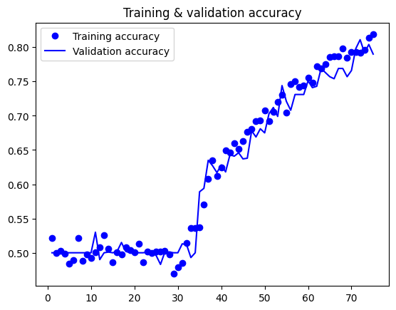

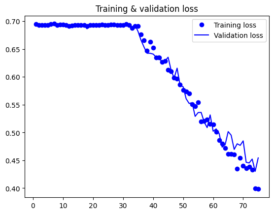

```python
import matplotlib.pyplot as plt
accuracy = history.history["accuracy"]
val_accuracy = history.history["val_accuracy"]
loss = history.history["loss"]
val_loss = history.history["val_loss"]
epochs = range(1, len(accuracy) + 1)
plt.plot(epochs, accuracy, "bo", label="Training accuracy")
plt.plot(epochs, val_accuracy, "b", label="Validation accuracy")
plt.title("Training & validation accuracy")
plt.legend()
plt.figure()
plt.plot(epochs, loss, "bo", label="Training loss")
plt.plot(epochs, val_loss, "b", label="Validation loss")
plt.title("Training & validation loss")
plt.legend()
plt.show()
```

```python
test_model = keras.models.load_model(
    "convnet_from_scratch_with_augmentation1.keras")
test_loss, test_acc = test_model.evaluate(test_dataset)
print(f"Test accuracy: {test_acc:.3f}")
```

```
32/32 ━━━━━━━━━━━━━━━━━━━━ 1s 30ms/step - accuracy: 0.7936 - loss: 0.4714
Test accuracy: 0.788
```

Using pretrained model with Feature extraction technique

Using the VGG16 convolutional base which describes the first several layers of the the architecture, which are in charge of taking hierarchical features out of input images.

```python
convolution_base = keras.applications.vgg16.VGG16(
    weights="imagenet",
    include_top=False,
    input_shape=(180, 180, 3))
```

```
Downloading data from https://storage.googleapis.com/tensorflow/keras-applications/vgg16/vgg16_weights_tf_dim_ordering_tf_kernels_notop.h5
58889256/58889256 ━━━━━━━━━━━━━━━━━━━━ 3s 0us/step
```

```python
convolution_base.summary()
```

```
Model: "vgg16"
```

```
┏━━━━━━━━━━━━━━━━━━━━━━━━━━━━━━━━━━━━━━┳━━━━━━━━━━━━━━━━━━━━━━━━━━━━━┳━━━━━━━━━━━━━━━━━┓
┃ Layer (type)                         ┃ Output Shape                ┃         Param # ┃
┡━━━━━━━━━━━━━━━━━━━━━━━━━━━━━━━━━━━━━━╇━━━━━━━━━━━━━━━━━━━━━━━━━━━━━╇━━━━━━━━━━━━━━━━━┩
│ input_layer_4 (InputLayer)           │ (None, 180, 180, 3)         │               0 │
├──────────────────────────────────────┼─────────────────────────────┼─────────────────┤
│ block1_conv1 (Conv2D)                │ (None, 180, 180, 64)        │           1,792 │
├──────────────────────────────────────┼─────────────────────────────┼─────────────────┤
│ block1_conv2 (Conv2D)                │ (None, 180, 180, 64)        │          36,928 │
├──────────────────────────────────────┼─────────────────────────────┼─────────────────┤
│ block1_pool (MaxPooling2D)           │ (None, 90, 90, 64)          │               0 │
├──────────────────────────────────────┼─────────────────────────────┼─────────────────┤
│ block2_conv1 (Conv2D)                │ (None, 90, 90, 128)         │          73,856 │
├──────────────────────────────────────┼─────────────────────────────┼─────────────────┤
│ block2_conv2 (Conv2D)                │ (None, 90, 90, 128)         │         147,584 │
├──────────────────────────────────────┼─────────────────────────────┼─────────────────┤
│ block2_pool (MaxPooling2D)           │ (None, 45, 45, 128)         │               0 │
├──────────────────────────────────────┼─────────────────────────────┼─────────────────┤
│ block3_conv1 (Conv2D)                │ (None, 45, 45, 256)         │         295,168 │
├──────────────────────────────────────┼─────────────────────────────┼─────────────────┤
│ block3_conv2 (Conv2D)                │ (None, 45, 45, 256)         │         590,080 │
├──────────────────────────────────────┼─────────────────────────────┼─────────────────┤
│ block3_conv3 (Conv2D)                │ (None, 45, 45, 256)         │         590,080 │
├──────────────────────────────────────┼─────────────────────────────┼─────────────────┤
│ block3_pool (MaxPooling2D)           │ (None, 22, 22, 256)         │               0 │
├──────────────────────────────────────┼─────────────────────────────┼─────────────────┤
│ block4_conv1 (Conv2D)                │ (None, 22, 22, 512)         │       1,180,160 │
├──────────────────────────────────────┼─────────────────────────────┼─────────────────┤
│ block4_conv2 (Conv2D)                │ (None, 22, 22, 512)         │       2,359,808 │
├──────────────────────────────────────┼─────────────────────────────┼─────────────────┤
│ block4_conv3 (Conv2D)                │ (None, 22, 22, 512)         │       2,359,808 │
├──────────────────────────────────────┼─────────────────────────────┼─────────────────┤
│ block4_pool (MaxPooling2D)           │ (None, 11, 11, 512)         │               0 │
├──────────────────────────────────────┼─────────────────────────────┼─────────────────┤
│ block5_conv1 (Conv2D)                │ (None, 11, 11, 512)         │       2,359,808 │
├──────────────────────────────────────┼─────────────────────────────┼─────────────────┤
│ block5_conv2 (Conv2D)                │ (None, 11, 11, 512)         │       2,359,808 │
├──────────────────────────────────────┼─────────────────────────────┼─────────────────┤
│ block5_conv3 (Conv2D)                │ (None, 11, 11, 512)         │       2,359,808 │
├──────────────────────────────────────┼─────────────────────────────┼─────────────────┤
│ block5_pool (MaxPooling2D)           │ (None, 5, 5, 512)           │               0 │
└──────────────────────────────────────┴─────────────────────────────┴─────────────────┘
```

```
 Total params: 14,714,688 (56.13 MB)
```

```
 Trainable params: 14,714,688 (56.13 MB)
```

```
 Non-trainable params: 0 (0.00 B)
```

Feature extraction without data augmentation using a pretrained model

```python
import numpy as np

def get_features_and_labels(dataset):
    all_features = []
    all_labels = []
    for images, labels in dataset:
        preprocessed_images = keras.applications.vgg16.preprocess_input(images)
        features = convolution_base.predict(preprocessed_images)
        all_features.append(features)
        all_labels.append(labels)
    return np.concatenate(all_features), np.concatenate(all_labels)

train_features, train_labels =  get_features_and_labels(train_dataset)
val_features, val_labels =  get_features_and_labels(validation_dataset)
test_features, test_labels =  get_features_and_labels(test_dataset)
```

[output not shown]

[output cut: 72 more lines]

[output not shown]

```python
train_features.shape
```

```
(2000, 5, 5, 512)
```

```python
inputs = keras.Input(shape=(5, 5, 512))
x = layers.Flatten()(inputs)
x = layers.Dense(256)(x)
x = layers.Dropout(0.5)(x)
outputs = layers.Dense(1, activation="sigmoid")(x)
model = keras.Model(inputs, outputs)
model.compile(loss="binary_crossentropy",
              optimizer="rmsprop",
              metrics=["accuracy"])

callbacks = [
    keras.callbacks.ModelCheckpoint(
      filepath="feature_extraction.keras",
      save_best_only=True,
      monitor="val_loss")
]
history = model.fit(
    train_features, train_labels,
    epochs=40,
    validation_data=(val_features, val_labels),
    callbacks=callbacks)
```

```
63/63 ━━━━━━━━━━━━━━━━━━━━ 4s 34ms/step - accuracy: 0.8756 - loss: 25.7750 - val_accuracy: 0.8400 - val_loss: 47.5852
63/63 ━━━━━━━━━━━━━━━━━━━━ 1s 8ms/step - accuracy: 0.9694 - loss: 6.5444 - val_accuracy: 0.9730 - val_loss: 5.3738
63/63 ━━━━━━━━━━━━━━━━━━━━ 0s 5ms/step - accuracy: 0.9844 - loss: 2.2113 - val_accuracy: 0.9730 - val_loss: 6.4333
63/63 ━━━━━━━━━━━━━━━━━━━━ 1s 9ms/step - accuracy: 0.9902 - loss: 1.6097 - val_accuracy: 0.9720 - val_loss: 4.8412
63/63 ━━━━━━━━━━━━━━━━━━━━ 1s 8ms/step - accuracy: 0.9959 - loss: 0.6213 - val_accuracy: 0.9760 - val_loss: 4.6803
63/63 ━━━━━━━━━━━━━━━━━━━━ 1s 10ms/step - accuracy: 0.9942 - loss: 0.4310 - val_accuracy: 0.9780 - val_loss: 3.5343
63/63 ━━━━━━━━━━━━━━━━━━━━ 1s 6ms/step - accuracy: 0.9927 - loss: 1.0254 - val_accuracy: 0.9840 - val_loss: 3.8621
63/63 ━━━━━━━━━━━━━━━━━━━━ 0s 6ms/step - accuracy: 0.9949 - loss: 0.9024 - val_accuracy: 0.9820 - val_loss: 4.2869
63/63 ━━━━━━━━━━━━━━━━━━━━ 1s 7ms/step - accuracy: 0.9965 - loss: 0.1103 - val_accuracy: 0.9750 - val_loss: 5.2426
63/63 ━━━━━━━━━━━━━━━━━━━━ 0s 5ms/step - accuracy: 0.9991 - loss: 0.1595 - val_accuracy: 0.9820 - val_loss: 4.1515
63/63 ━━━━━━━━━━━━━━━━━━━━ 0s 5ms/step - accuracy: 0.9992 - loss: 0.0535 - val_accuracy: 0.9840 - val_loss: 3.8375
63/63 ━━━━━━━━━━━━━━━━━━━━ 1s 4ms/step - accuracy: 0.9949 - loss: 0.8349 - val_accuracy: 0.9780 - val_loss: 4.2980
63/63 ━━━━━━━━━━━━━━━━━━━━ 0s 4ms/step - accuracy: 0.9952 - loss: 0.2378 - val_accuracy: 0.9750 - val_loss: 5.7601
63/63 ━━━━━━━━━━━━━━━━━━━━ 0s 4ms/step - accuracy: 0.9958 - loss: 0.4315 - val_accuracy: 0.9720 - val_loss: 6.1017
63/63 ━━━━━━━━━━━━━━━━━━━━ 0s 4ms/step - accuracy: 0.9994 - loss: 0.0643 - val_accuracy: 0.9800 - val_loss: 3.9363
63/63 ━━━━━━━━━━━━━━━━━━━━ 0s 3ms/step - accuracy: 0.9998 - loss: 0.0155 - val_accuracy: 0.9800 - val_loss: 4.1223
63/63 ━━━━━━━━━━━━━━━━━━━━ 0s 4ms/step - accuracy: 0.9984 - loss: 0.0952 - val_accuracy: 0.9740 - val_loss: 6.5556
63/63 ━━━━━━━━━━━━━━━━━━━━ 0s 4ms/step - accuracy: 0.9977 - loss: 0.6942 - val_accuracy: 0.9820 - val_loss: 3.9950
63/63 ━━━━━━━━━━━━━━━━━━━━ 0s 4ms/step - accuracy: 0.9970 - loss: 0.4450 - val_accuracy: 0.9820 - val_loss: 3.9779
63/63 ━━━━━━━━━━━━━━━━━━━━ 0s 3ms/step - accuracy: 1.0000 - loss: 9.1143e-14 - val_accuracy: 0.9820 - val_loss: 3.9779
63/63 ━━━━━━━━━━━━━━━━━━━━ 0s 4ms/step - accuracy: 1.0000 - loss: 8.0309e-13 - val_accuracy: 0.9820 - val_loss: 3.9779
63/63 ━━━━━━━━━━━━━━━━━━━━ 0s 4ms/step - accuracy: 0.9997 - loss: 0.0310 - val_accuracy: 0.9820 - val_loss: 5.3180
63/63 ━━━━━━━━━━━━━━━━━━━━ 0s 3ms/step - accuracy: 0.9996 - loss: 0.0400 - val_accuracy: 0.9810 - val_loss: 4.5393
63/63 ━━━━━━━━━━━━━━━━━━━━ 0s 4ms/step - accuracy: 1.0000 - loss: 7.7287e-07 - val_accuracy: 0.9810 - val_loss: 4.5716
63/63 ━━━━━━━━━━━━━━━━━━━━ 0s 4ms/step - accuracy: 0.9991 - loss: 0.0401 - val_accuracy: 0.9830 - val_loss: 4.6812
63/63 ━━━━━━━━━━━━━━━━━━━━ 0s 3ms/step - accuracy: 0.9991 - loss: 0.0515 - val_accuracy: 0.9730 - val_loss: 7.4718
63/63 ━━━━━━━━━━━━━━━━━━━━ 0s 4ms/step - accuracy: 0.9983 - loss: 0.1135 - val_accuracy: 0.9800 - val_loss: 5.0380
63/63 ━━━━━━━━━━━━━━━━━━━━ 0s 4ms/step - accuracy: 0.9994 - loss: 0.0294 - val_accuracy: 0.9810 - val_loss: 4.4556
63/63 ━━━━━━━━━━━━━━━━━━━━ 0s 4ms/step - accuracy: 0.9997 - loss: 0.0088 - val_accuracy: 0.9750 - val_loss: 5.5643
63/63 ━━━━━━━━━━━━━━━━━━━━ 0s 4ms/step - accuracy: 0.9994 - loss: 0.0349 - val_accuracy: 0.9820 - val_loss: 4.8367
63/63 ━━━━━━━━━━━━━━━━━━━━ 0s 4ms/step - accuracy: 0.9989 - loss: 0.0392 - val_accuracy: 0.9790 - val_loss: 5.2452
63/63 ━━━━━━━━━━━━━━━━━━━━ 0s 4ms/step - accuracy: 1.0000 - loss: 3.0856e-34 - val_accuracy: 0.9790 - val_loss: 5.2452
63/63 ━━━━━━━━━━━━━━━━━━━━ 0s 4ms/step - accuracy: 1.0000 - loss: 0.0000e+00 - val_accuracy: 0.9790 - val_loss: 5.2452
63/63 ━━━━━━━━━━━━━━━━━━━━ 0s 4ms/step - accuracy: 1.0000 - loss: 0.0020 - val_accuracy: 0.9710 - val_loss: 7.0786
63/63 ━━━━━━━━━━━━━━━━━━━━ 0s 4ms/step - accuracy: 0.9987 - loss: 0.3955 - val_accuracy: 0.9730 - val_loss: 6.9198
63/63 ━━━━━━━━━━━━━━━━━━━━ 0s 4ms/step - accuracy: 0.9989 - loss: 0.0312 - val_accuracy: 0.9800 - val_loss: 4.3969
63/63 ━━━━━━━━━━━━━━━━━━━━ 0s 3ms/step - accuracy: 1.0000 - loss: 0.0000e+00 - val_accuracy: 0.9800 - val_loss: 4.3969
63/63 ━━━━━━━━━━━━━━━━━━━━ 0s 3ms/step - accuracy: 1.0000 - loss: 0.0000e+00 - val_accuracy: 0.9800 - val_loss: 4.3969
63/63 ━━━━━━━━━━━━━━━━━━━━ 0s 4ms/step - accuracy: 1.0000 - loss: 1.1448e-34 - val_accuracy: 0.9800 - val_loss: 4.3969
63/63 ━━━━━━━━━━━━━━━━━━━━ 0s 4ms/step - accuracy: 1.0000 - loss: 0.0000e+00 - val_accuracy: 0.9800 - val_loss: 4.3969
```

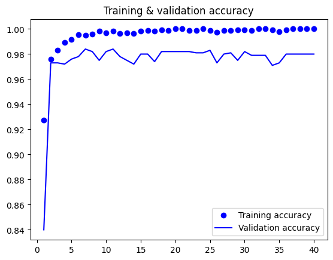

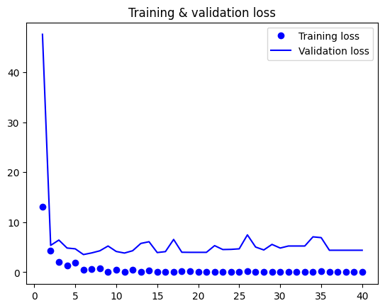

```python
import matplotlib.pyplot as plt
accuracy = history.history["accuracy"]
val_accuracy = history.history["val_accuracy"]
loss = history.history["loss"]
val_loss = history.history["val_loss"]
epochs = range(1, len(accuracy) + 1)
plt.plot(epochs, accuracy, "bo", label="Training accuracy")
plt.plot(epochs, val_accuracy, "b", label="Validation accuracy")
plt.title("Training & validation accuracy")
plt.legend()
plt.figure()
plt.plot(epochs, loss, "bo", label="Training loss")
plt.plot(epochs, val_loss, "b", label="Validation loss")
plt.title("Training & validation loss")
plt.legend()
plt.show()
```

Freezing the VGG16 convolutional base as in feature extraction we freeze the initial trained base

```python
convolution_base  = keras.applications.vgg16.VGG16(
    weights="imagenet",
    include_top=False)
convolution_base.trainable = False
```

```python
convolution_base.trainable = True
print("The number of trainable weights required to use the convolution base before it freezes is as follows:", len(convolution_base.trainable_weights))
```

```
The number of trainable weights required to use the convolution base before it freezes is as follows: 26
```

```python
convolution_base.trainable = False
print("After the convolution base is frozen, this is the total quantity of trainable weights:", len(convolution_base.trainable_weights))
```

```
After the convolution base is frozen, this is the total quantity of trainable weights: 0
```

Adding data augmentation:

```python
augmentation2 = keras.Sequential(
[
layers.RandomFlip("horizontal"),
layers.RandomRotation(0.1),
layers.RandomZoom(0.2),
]
)
input22 = keras.Input(shape=(180, 180, 3))
x1 = augmentation2(input22)
x1 =keras.layers.Lambda(
lambda x: keras.applications.vgg16.preprocess_input(x))(x1)
x1 = convolution_base(x1)
x1 = layers.Flatten()(x1)
x1 = layers.Dense(256)(x1)
x1 = layers.Dropout(0.5)(x1)
outputs = layers.Dense(1, activation="sigmoid")(x1)
model = keras.Model(input22, outputs)
model.compile(loss="binary_crossentropy",
optimizer="rmsprop",
metrics=["accuracy"])
```

```python
callbacks = [
    keras.callbacks.ModelCheckpoint(
        filepath="feature_extraction_with_data_augmentation.keras",
        save_best_only=True,
        monitor="val_loss")
]
history = model.fit(
    train_dataset,
    epochs=75,
    validation_data=validation_dataset,
    callbacks=callbacks)
```

```
63/63 ━━━━━━━━━━━━━━━━━━━━ 18s 219ms/step - accuracy: 0.8412 - loss: 28.9973 - val_accuracy: 0.9730 - val_loss: 3.2762
63/63 ━━━━━━━━━━━━━━━━━━━━ 10s 159ms/step - accuracy: 0.9537 - loss: 5.8717 - val_accuracy: 0.9620 - val_loss: 5.3741
63/63 ━━━━━━━━━━━━━━━━━━━━ 12s 190ms/step - accuracy: 0.9414 - loss: 6.9206 - val_accuracy: 0.9650 - val_loss: 6.3047
63/63 ━━━━━━━━━━━━━━━━━━━━ 19s 160ms/step - accuracy: 0.9560 - loss: 5.9219 - val_accuracy: 0.9770 - val_loss: 4.4861
63/63 ━━━━━━━━━━━━━━━━━━━━ 10s 159ms/step - accuracy: 0.9678 - loss: 3.8125 - val_accuracy: 0.9770 - val_loss: 4.7825
63/63 ━━━━━━━━━━━━━━━━━━━━ 10s 161ms/step - accuracy: 0.9686 - loss: 5.0246 - val_accuracy: 0.9780 - val_loss: 3.6926
63/63 ━━━━━━━━━━━━━━━━━━━━ 10s 164ms/step - accuracy: 0.9738 - loss: 3.5145 - val_accuracy: 0.9780 - val_loss: 3.7855
63/63 ━━━━━━━━━━━━━━━━━━━━ 13s 203ms/step - accuracy: 0.9646 - loss: 4.6581 - val_accuracy: 0.9740 - val_loss: 2.7476
63/63 ━━━━━━━━━━━━━━━━━━━━ 20s 191ms/step - accuracy: 0.9771 - loss: 3.3971 - val_accuracy: 0.9740 - val_loss: 3.1465
63/63 ━━━━━━━━━━━━━━━━━━━━ 19s 162ms/step - accuracy: 0.9782 - loss: 2.4251 - val_accuracy: 0.9540 - val_loss: 9.3211
63/63 ━━━━━━━━━━━━━━━━━━━━ 22s 189ms/step - accuracy: 0.9732 - loss: 2.5099 - val_accuracy: 0.9710 - val_loss: 5.2024
63/63 ━━━━━━━━━━━━━━━━━━━━ 19s 162ms/step - accuracy: 0.9749 - loss: 3.4155 - val_accuracy: 0.9800 - val_loss: 3.3537
63/63 ━━━━━━━━━━━━━━━━━━━━ 20s 162ms/step - accuracy: 0.9821 - loss: 1.4118 - val_accuracy: 0.9700 - val_loss: 5.4793
63/63 ━━━━━━━━━━━━━━━━━━━━ 20s 159ms/step - accuracy: 0.9807 - loss: 1.8455 - val_accuracy: 0.9790 - val_loss: 3.4316
63/63 ━━━━━━━━━━━━━━━━━━━━ 12s 191ms/step - accuracy: 0.9785 - loss: 1.7809 - val_accuracy: 0.9750 - val_loss: 3.5707
63/63 ━━━━━━━━━━━━━━━━━━━━ 20s 189ms/step - accuracy: 0.9881 - loss: 1.0868 - val_accuracy: 0.9750 - val_loss: 4.9817
63/63 ━━━━━━━━━━━━━━━━━━━━ 10s 160ms/step - accuracy: 0.9809 - loss: 2.1662 - val_accuracy: 0.9800 - val_loss: 2.8585
63/63 ━━━━━━━━━━━━━━━━━━━━ 10s 162ms/step - accuracy: 0.9801 - loss: 2.2183 - val_accuracy: 0.9610 - val_loss: 6.3050
63/63 ━━━━━━━━━━━━━━━━━━━━ 12s 191ms/step - accuracy: 0.9899 - loss: 0.4898 - val_accuracy: 0.9790 - val_loss: 3.1296
63/63 ━━━━━━━━━━━━━━━━━━━━ 12s 190ms/step - accuracy: 0.9820 - loss: 1.2387 - val_accuracy: 0.9820 - val_loss: 2.8968
63/63 ━━━━━━━━━━━━━━━━━━━━ 21s 191ms/step - accuracy: 0.9770 - loss: 1.6562 - val_accuracy: 0.9720 - val_loss: 3.9494
63/63 ━━━━━━━━━━━━━━━━━━━━ 13s 199ms/step - accuracy: 0.9849 - loss: 1.7551 - val_accuracy: 0.9780 - val_loss: 2.4949
63/63 ━━━━━━━━━━━━━━━━━━━━ 10s 162ms/step - accuracy: 0.9873 - loss: 1.1704 - val_accuracy: 0.9800 - val_loss: 3.1444
63/63 ━━━━━━━━━━━━━━━━━━━━ 10s 166ms/step - accuracy: 0.9851 - loss: 1.2841 - val_accuracy: 0.9820 - val_loss: 2.5546
63/63 ━━━━━━━━━━━━━━━━━━━━ 11s 168ms/step - accuracy: 0.9846 - loss: 0.9196 - val_accuracy: 0.9760 - val_loss: 2.6331
63/63 ━━━━━━━━━━━━━━━━━━━━ 22s 194ms/step - accuracy: 0.9837 - loss: 1.3762 - val_accuracy: 0.9720 - val_loss: 4.2192
63/63 ━━━━━━━━━━━━━━━━━━━━ 13s 206ms/step - accuracy: 0.9784 - loss: 1.3125 - val_accuracy: 0.9830 - val_loss: 2.0772
63/63 ━━━━━━━━━━━━━━━━━━━━ 18s 162ms/step - accuracy: 0.9810 - loss: 1.2493 - val_accuracy: 0.9790 - val_loss: 2.5608
63/63 ━━━━━━━━━━━━━━━━━━━━ 10s 160ms/step - accuracy: 0.9792 - loss: 1.2118 - val_accuracy: 0.9760 - val_loss: 3.0998
63/63 ━━━━━━━━━━━━━━━━━━━━ 12s 193ms/step - accuracy: 0.9911 - loss: 0.4064 - val_accuracy: 0.9790 - val_loss: 2.4920
63/63 ━━━━━━━━━━━━━━━━━━━━ 18s 160ms/step - accuracy: 0.9934 - loss: 0.3337 - val_accuracy: 0.9780 - val_loss: 2.5993
63/63 ━━━━━━━━━━━━━━━━━━━━ 10s 162ms/step - accuracy: 0.9796 - loss: 1.2937 - val_accuracy: 0.9800 - val_loss: 2.0800
63/63 ━━━━━━━━━━━━━━━━━━━━ 12s 191ms/step - accuracy: 0.9866 - loss: 0.6537 - val_accuracy: 0.9800 - val_loss: 2.2413
63/63 ━━━━━━━━━━━━━━━━━━━━ 10s 161ms/step - accuracy: 0.9859 - loss: 0.9990 - val_accuracy: 0.9740 - val_loss: 2.5550
63/63 ━━━━━━━━━━━━━━━━━━━━ 10s 165ms/step - accuracy: 0.9909 - loss: 0.3679 - val_accuracy: 0.9780 - val_loss: 2.2979
63/63 ━━━━━━━━━━━━━━━━━━━━ 11s 168ms/step - accuracy: 0.9908 - loss: 0.3462 - val_accuracy: 0.9810 - val_loss: 2.7602
63/63 ━━━━━━━━━━━━━━━━━━━━ 22s 193ms/step - accuracy: 0.9843 - loss: 0.6593 - val_accuracy: 0.9820 - val_loss: 2.3917
63/63 ━━━━━━━━━━━━━━━━━━━━ 20s 192ms/step - accuracy: 0.9886 - loss: 0.4956 - val_accuracy: 0.9790 - val_loss: 2.3061
63/63 ━━━━━━━━━━━━━━━━━━━━ 21s 194ms/step - accuracy: 0.9954 - loss: 0.1153 - val_accuracy: 0.9810 - val_loss: 2.1299
63/63 ━━━━━━━━━━━━━━━━━━━━ 19s 165ms/step - accuracy: 0.9925 - loss: 0.4166 - val_accuracy: 0.9760 - val_loss: 2.3286
```

[output cut: 20 more lines]

```
63/63 ━━━━━━━━━━━━━━━━━━━━ 20s 162ms/step - accuracy: 0.9892 - loss: 0.5851 - val_accuracy: 0.9800 - val_loss: 1.4522
63/63 ━━━━━━━━━━━━━━━━━━━━ 20s 162ms/step - accuracy: 0.9909 - loss: 0.4592 - val_accuracy: 0.9810 - val_loss: 1.8267
63/63 ━━━━━━━━━━━━━━━━━━━━ 20s 162ms/step - accuracy: 0.9954 - loss: 0.1825 - val_accuracy: 0.9790 - val_loss: 1.9904
63/63 ━━━━━━━━━━━━━━━━━━━━ 10s 165ms/step - accuracy: 0.9913 - loss: 0.3303 - val_accuracy: 0.9860 - val_loss: 1.4635
63/63 ━━━━━━━━━━━━━━━━━━━━ 11s 178ms/step - accuracy: 0.9944 - loss: 0.2325 - val_accuracy: 0.9830 - val_loss: 1.2671
63/63 ━━━━━━━━━━━━━━━━━━━━ 20s 165ms/step - accuracy: 0.9897 - loss: 0.3884 - val_accuracy: 0.9830 - val_loss: 1.4417
63/63 ━━━━━━━━━━━━━━━━━━━━ 22s 193ms/step - accuracy: 0.9925 - loss: 0.2371 - val_accuracy: 0.9830 - val_loss: 1.6081
63/63 ━━━━━━━━━━━━━━━━━━━━ 11s 167ms/step - accuracy: 0.9882 - loss: 0.4921 - val_accuracy: 0.9800 - val_loss: 1.8671
63/63 ━━━━━━━━━━━━━━━━━━━━ 22s 191ms/step - accuracy: 0.9963 - loss: 0.1660 - val_accuracy: 0.9830 - val_loss: 1.6689
63/63 ━━━━━━━━━━━━━━━━━━━━ 10s 163ms/step - accuracy: 0.9967 - loss: 0.1525 - val_accuracy: 0.9810 - val_loss: 1.6841
63/63 ━━━━━━━━━━━━━━━━━━━━ 10s 165ms/step - accuracy: 0.9908 - loss: 0.3531 - val_accuracy: 0.9830 - val_loss: 1.9276
63/63 ━━━━━━━━━━━━━━━━━━━━ 12s 192ms/step - accuracy: 0.9928 - loss: 0.4965 - val_accuracy: 0.9780 - val_loss: 2.2437
63/63 ━━━━━━━━━━━━━━━━━━━━ 21s 192ms/step - accuracy: 0.9890 - loss: 0.4092 - val_accuracy: 0.9800 - val_loss: 2.4140
63/63 ━━━━━━━━━━━━━━━━━━━━ 19s 161ms/step - accuracy: 0.9907 - loss: 0.6050 - val_accuracy: 0.9820 - val_loss: 2.2798
63/63 ━━━━━━━━━━━━━━━━━━━━ 10s 163ms/step - accuracy: 0.9934 - loss: 0.3279 - val_accuracy: 0.9820 - val_loss: 2.0438
```

A pretrained VGG16 model with Fine-tuning

Fine-tuning the pretrained model which already discovered some useful characteristics from a large set of data, speed-to-convergence is accelerated as compared to training from scratch. The model may overfit the dataset that the model is tuned on if it is not fine-tunned on a new dataset. This may result in it meshing its learned features better to the features of this new dataset leading to improved generalization performance.

```python
convolution_base.summary()
```

```
Model: "vgg16"
```

```
┏━━━━━━━━━━━━━━━━━━━━━━━━━━━━━━━━━━━━━━┳━━━━━━━━━━━━━━━━━━━━━━━━━━━━━┳━━━━━━━━━━━━━━━━━┓
┃ Layer (type)                         ┃ Output Shape                ┃         Param # ┃
┡━━━━━━━━━━━━━━━━━━━━━━━━━━━━━━━━━━━━━━╇━━━━━━━━━━━━━━━━━━━━━━━━━━━━━╇━━━━━━━━━━━━━━━━━┩
│ input_layer_6 (InputLayer)           │ (None, None, None, 3)       │               0 │
├──────────────────────────────────────┼─────────────────────────────┼─────────────────┤
│ block1_conv1 (Conv2D)                │ (None, None, None, 64)      │           1,792 │
├──────────────────────────────────────┼─────────────────────────────┼─────────────────┤
│ block1_conv2 (Conv2D)                │ (None, None, None, 64)      │          36,928 │
├──────────────────────────────────────┼─────────────────────────────┼─────────────────┤
│ block1_pool (MaxPooling2D)           │ (None, None, None, 64)      │               0 │
├──────────────────────────────────────┼─────────────────────────────┼─────────────────┤
│ block2_conv1 (Conv2D)                │ (None, None, None, 128)     │          73,856 │
├──────────────────────────────────────┼─────────────────────────────┼─────────────────┤
│ block2_conv2 (Conv2D)                │ (None, None, None, 128)     │         147,584 │
├──────────────────────────────────────┼─────────────────────────────┼─────────────────┤
│ block2_pool (MaxPooling2D)           │ (None, None, None, 128)     │               0 │
├──────────────────────────────────────┼─────────────────────────────┼─────────────────┤
│ block3_conv1 (Conv2D)                │ (None, None, None, 256)     │         295,168 │
├──────────────────────────────────────┼─────────────────────────────┼─────────────────┤
│ block3_conv2 (Conv2D)                │ (None, None, None, 256)     │         590,080 │
├──────────────────────────────────────┼─────────────────────────────┼─────────────────┤
│ block3_conv3 (Conv2D)                │ (None, None, None, 256)     │         590,080 │
├──────────────────────────────────────┼─────────────────────────────┼─────────────────┤
│ block3_pool (MaxPooling2D)           │ (None, None, None, 256)     │               0 │
├──────────────────────────────────────┼─────────────────────────────┼─────────────────┤
│ block4_conv1 (Conv2D)                │ (None, None, None, 512)     │       1,180,160 │
├──────────────────────────────────────┼─────────────────────────────┼─────────────────┤
│ block4_conv2 (Conv2D)                │ (None, None, None, 512)     │       2,359,808 │
├──────────────────────────────────────┼─────────────────────────────┼─────────────────┤
│ block4_conv3 (Conv2D)                │ (None, None, None, 512)     │       2,359,808 │
├──────────────────────────────────────┼─────────────────────────────┼─────────────────┤
│ block4_pool (MaxPooling2D)           │ (None, None, None, 512)     │               0 │
├──────────────────────────────────────┼─────────────────────────────┼─────────────────┤
│ block5_conv1 (Conv2D)                │ (None, None, None, 512)     │       2,359,808 │
├──────────────────────────────────────┼─────────────────────────────┼─────────────────┤
│ block5_conv2 (Conv2D)                │ (None, None, None, 512)     │       2,359,808 │
├──────────────────────────────────────┼─────────────────────────────┼─────────────────┤
│ block5_conv3 (Conv2D)                │ (None, None, None, 512)     │       2,359,808 │
├──────────────────────────────────────┼─────────────────────────────┼─────────────────┤
│ block5_pool (MaxPooling2D)           │ (None, None, None, 512)     │               0 │
└──────────────────────────────────────┴─────────────────────────────┴─────────────────┘
```

```
 Total params: 14,714,688 (56.13 MB)
```

```
 Trainable params: 0 (0.00 B)
```

```
 Non-trainable params: 14,714,688 (56.13 MB)
```

```python
convolution_base.trainable = True
for layer in convolution_base.layers[:-4]:
    layer.trainable = False
```

```python
model.compile(loss="binary_crossentropy",
              optimizer=keras.optimizers.RMSprop(learning_rate=1e-5),
              metrics=["accuracy"])

callbacks = [
    keras.callbacks.ModelCheckpoint(
        filepath="fine_tuning.keras",
        save_best_only=True,
        monitor="val_loss")
]
history = model.fit(
    train_dataset,
    epochs=50,
    validation_data=validation_dataset,
    callbacks=callbacks)
```

```
63/63 ━━━━━━━━━━━━━━━━━━━━ 15s 196ms/step - accuracy: 0.9923 - loss: 0.4354 - val_accuracy: 0.9830 - val_loss: 1.9816
63/63 ━━━━━━━━━━━━━━━━━━━━ 22s 229ms/step - accuracy: 0.9921 - loss: 0.5513 - val_accuracy: 0.9830 - val_loss: 1.7654
63/63 ━━━━━━━━━━━━━━━━━━━━ 13s 199ms/step - accuracy: 0.9941 - loss: 0.1930 - val_accuracy: 0.9790 - val_loss: 1.7059
63/63 ━━━━━━━━━━━━━━━━━━━━ 22s 222ms/step - accuracy: 0.9907 - loss: 0.3738 - val_accuracy: 0.9800 - val_loss: 1.5198
63/63 ━━━━━━━━━━━━━━━━━━━━ 11s 181ms/step - accuracy: 0.9948 - loss: 0.1671 - val_accuracy: 0.9830 - val_loss: 1.8897
63/63 ━━━━━━━━━━━━━━━━━━━━ 11s 179ms/step - accuracy: 0.9892 - loss: 0.5627 - val_accuracy: 0.9770 - val_loss: 2.1359
63/63 ━━━━━━━━━━━━━━━━━━━━ 21s 182ms/step - accuracy: 0.9935 - loss: 0.3442 - val_accuracy: 0.9750 - val_loss: 1.9688
63/63 ━━━━━━━━━━━━━━━━━━━━ 21s 184ms/step - accuracy: 0.9892 - loss: 0.4236 - val_accuracy: 0.9840 - val_loss: 1.8988
63/63 ━━━━━━━━━━━━━━━━━━━━ 20s 180ms/step - accuracy: 0.9949 - loss: 0.4355 - val_accuracy: 0.9800 - val_loss: 1.7999
63/63 ━━━━━━━━━━━━━━━━━━━━ 23s 213ms/step - accuracy: 0.9948 - loss: 0.2176 - val_accuracy: 0.9770 - val_loss: 1.8167
63/63 ━━━━━━━━━━━━━━━━━━━━ 19s 182ms/step - accuracy: 0.9947 - loss: 0.2714 - val_accuracy: 0.9770 - val_loss: 2.1169
63/63 ━━━━━━━━━━━━━━━━━━━━ 20s 180ms/step - accuracy: 0.9907 - loss: 0.1851 - val_accuracy: 0.9840 - val_loss: 1.7397
63/63 ━━━━━━━━━━━━━━━━━━━━ 12s 183ms/step - accuracy: 0.9943 - loss: 0.1384 - val_accuracy: 0.9840 - val_loss: 1.8476
63/63 ━━━━━━━━━━━━━━━━━━━━ 22s 207ms/step - accuracy: 0.9971 - loss: 0.0968 - val_accuracy: 0.9840 - val_loss: 1.5738
63/63 ━━━━━━━━━━━━━━━━━━━━ 19s 182ms/step - accuracy: 0.9976 - loss: 0.0568 - val_accuracy: 0.9850 - val_loss: 1.6592
63/63 ━━━━━━━━━━━━━━━━━━━━ 21s 183ms/step - accuracy: 0.9957 - loss: 0.5166 - val_accuracy: 0.9810 - val_loss: 1.8070
63/63 ━━━━━━━━━━━━━━━━━━━━ 22s 207ms/step - accuracy: 0.9951 - loss: 0.1837 - val_accuracy: 0.9850 - val_loss: 1.5628
63/63 ━━━━━━━━━━━━━━━━━━━━ 21s 210ms/step - accuracy: 0.9992 - loss: 0.0174 - val_accuracy: 0.9830 - val_loss: 1.8657
63/63 ━━━━━━━━━━━━━━━━━━━━ 14s 222ms/step - accuracy: 0.9944 - loss: 0.1665 - val_accuracy: 0.9830 - val_loss: 1.5097
63/63 ━━━━━━━━━━━━━━━━━━━━ 19s 194ms/step - accuracy: 0.9971 - loss: 0.1979 - val_accuracy: 0.9820 - val_loss: 1.4941
63/63 ━━━━━━━━━━━━━━━━━━━━ 19s 175ms/step - accuracy: 0.9954 - loss: 0.1587 - val_accuracy: 0.9830 - val_loss: 1.5189
63/63 ━━━━━━━━━━━━━━━━━━━━ 21s 177ms/step - accuracy: 0.9953 - loss: 0.3448 - val_accuracy: 0.9800 - val_loss: 2.1360
63/63 ━━━━━━━━━━━━━━━━━━━━ 21s 181ms/step - accuracy: 0.9974 - loss: 0.2031 - val_accuracy: 0.9820 - val_loss: 1.6784
63/63 ━━━━━━━━━━━━━━━━━━━━ 13s 209ms/step - accuracy: 0.9914 - loss: 0.3330 - val_accuracy: 0.9840 - val_loss: 1.5765
63/63 ━━━━━━━━━━━━━━━━━━━━ 19s 179ms/step - accuracy: 0.9948 - loss: 0.1630 - val_accuracy: 0.9840 - val_loss: 1.8532
63/63 ━━━━━━━━━━━━━━━━━━━━ 20s 174ms/step - accuracy: 0.9973 - loss: 0.0407 - val_accuracy: 0.9820 - val_loss: 1.8105
63/63 ━━━━━━━━━━━━━━━━━━━━ 23s 219ms/step - accuracy: 0.9974 - loss: 0.1603 - val_accuracy: 0.9760 - val_loss: 2.4865
63/63 ━━━━━━━━━━━━━━━━━━━━ 18s 178ms/step - accuracy: 0.9962 - loss: 0.1669 - val_accuracy: 0.9810 - val_loss: 2.0515
63/63 ━━━━━━━━━━━━━━━━━━━━ 11s 174ms/step - accuracy: 0.9985 - loss: 0.0415 - val_accuracy: 0.9770 - val_loss: 3.3637
63/63 ━━━━━━━━━━━━━━━━━━━━ 11s 177ms/step - accuracy: 0.9978 - loss: 0.0224 - val_accuracy: 0.9820 - val_loss: 2.5705
63/63 ━━━━━━━━━━━━━━━━━━━━ 11s 181ms/step - accuracy: 0.9946 - loss: 0.0709 - val_accuracy: 0.9830 - val_loss: 2.1575
63/63 ━━━━━━━━━━━━━━━━━━━━ 22s 207ms/step - accuracy: 0.9979 - loss: 0.0342 - val_accuracy: 0.9850 - val_loss: 2.1468
63/63 ━━━━━━━━━━━━━━━━━━━━ 20s 206ms/step - accuracy: 0.9972 - loss: 0.0670 - val_accuracy: 0.9820 - val_loss: 2.2664
63/63 ━━━━━━━━━━━━━━━━━━━━ 19s 182ms/step - accuracy: 0.9990 - loss: 0.0770 - val_accuracy: 0.9810 - val_loss: 2.0757
63/63 ━━━━━━━━━━━━━━━━━━━━ 11s 176ms/step - accuracy: 0.9970 - loss: 0.1033 - val_accuracy: 0.9830 - val_loss: 2.0052
63/63 ━━━━━━━━━━━━━━━━━━━━ 21s 179ms/step - accuracy: 0.9981 - loss: 0.0557 - val_accuracy: 0.9800 - val_loss: 1.7794
63/63 ━━━━━━━━━━━━━━━━━━━━ 20s 175ms/step - accuracy: 0.9980 - loss: 0.0793 - val_accuracy: 0.9850 - val_loss: 1.8720
63/63 ━━━━━━━━━━━━━━━━━━━━ 13s 209ms/step - accuracy: 0.9988 - loss: 0.0407 - val_accuracy: 0.9840 - val_loss: 1.7562
63/63 ━━━━━━━━━━━━━━━━━━━━ 18s 174ms/step - accuracy: 0.9956 - loss: 0.0829 - val_accuracy: 0.9840 - val_loss: 1.6769
63/63 ━━━━━━━━━━━━━━━━━━━━ 21s 178ms/step - accuracy: 0.9967 - loss: 0.0511 - val_accuracy: 0.9800 - val_loss: 2.1946
63/63 ━━━━━━━━━━━━━━━━━━━━ 22s 208ms/step - accuracy: 0.9992 - loss: 0.0193 - val_accuracy: 0.9850 - val_loss: 1.7305
63/63 ━━━━━━━━━━━━━━━━━━━━ 18s 173ms/step - accuracy: 0.9985 - loss: 0.0038 - val_accuracy: 0.9820 - val_loss: 1.8437
63/63 ━━━━━━━━━━━━━━━━━━━━ 21s 178ms/step - accuracy: 0.9992 - loss: 0.0111 - val_accuracy: 0.9700 - val_loss: 3.5891
63/63 ━━━━━━━━━━━━━━━━━━━━ 22s 207ms/step - accuracy: 0.9967 - loss: 0.0438 - val_accuracy: 0.9780 - val_loss: 2.8906
63/63 ━━━━━━━━━━━━━━━━━━━━ 20s 203ms/step - accuracy: 0.9937 - loss: 0.3912 - val_accuracy: 0.9870 - val_loss: 1.6918
63/63 ━━━━━━━━━━━━━━━━━━━━ 21s 211ms/step - accuracy: 0.9975 - loss: 0.0443 - val_accuracy: 0.9820 - val_loss: 1.9703
63/63 ━━━━━━━━━━━━━━━━━━━━ 20s 207ms/step - accuracy: 0.9996 - loss: 0.0151 - val_accuracy: 0.9870 - val_loss: 1.7109
63/63 ━━━━━━━━━━━━━━━━━━━━ 21s 215ms/step - accuracy: 0.9975 - loss: 0.0445 - val_accuracy: 0.9880 - val_loss: 1.4771
63/63 ━━━━━━━━━━━━━━━━━━━━ 18s 178ms/step - accuracy: 0.9959 - loss: 0.2099 - val_accuracy: 0.9870 - val_loss: 1.6063
63/63 ━━━━━━━━━━━━━━━━━━━━ 20s 174ms/step - accuracy: 0.9990 - loss: 0.0547 - val_accuracy: 0.9850 - val_loss: 2.1361
```

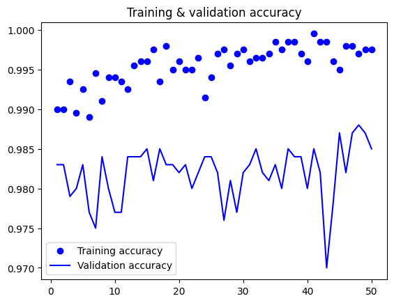

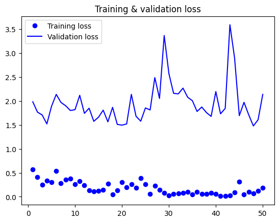

```python
import matplotlib.pyplot as plt
accuracy = history.history["accuracy"]
val_accuracy = history.history["val_accuracy"]
loss = history.history["loss"]
val_loss = history.history["val_loss"]
epochs = range(1, len(accuracy) + 1)
plt.plot(epochs, accuracy, "bo", label="Training accuracy")
plt.plot(epochs, val_accuracy, "b", label="Validation accuracy")
plt.title("Training & validation accuracy")
plt.legend()
plt.figure()
plt.plot(epochs, loss, "bo", label="Training loss")
plt.plot(epochs, val_loss, "b", label="Validation loss")
plt.title("Training & validation loss")
plt.legend()
plt.show()
```